# R veri Görselleştirme Ders Notu

# 3. **GRAFİK BÖLME**

```r
df<- tibble(
  c= factor(rep(c("e","k") , each=600)),
  m = c(rnorm(600, mean= 80), rnorm(600, mean=82)),
  w= c(rnorm(600, mean= 80), rnorm(600, mean=82)),
  me= factor(rep(c("a","b","c"), each= 400))
)
df
```

```
## # A tibble: 1,200 × 4
##    c         m     w me
##    <fct> <dbl> <dbl> <fct>
##  1 e      80.6  79.2 a
##  2 e      77.7  78.9 a
##  3 e      80.1  79.8 a
##  4 e      80.2  77.6 a
##  5 e      80.2  78.8 a
##  6 e      79.8  79.4 a
##  7 e      79.1  79.7 a
##  8 e      79.6  81.8 a
##  9 e      81.5  79.2 a
## 10 e      79.7  80.3 a
## # … with 1,190 more rows
```

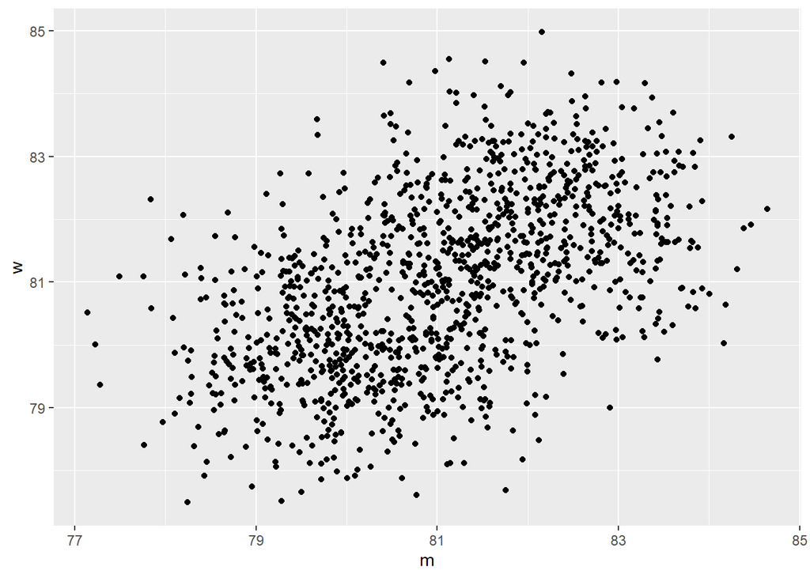

```r
df<- tibble(
  c= factor(rep(c("e","k") , each=600)),
  m = c(rnorm(600, mean= 80), rnorm(600, mean=82)),
  w= c(rnorm(600, mean= 80), rnorm(600, mean=82)),
  me= factor(rep(c("a","b","c"), each= 400))
)
t <- ggplot(df, aes(m,w)) +
  geom_point()
t
```

sütun bazında bölme

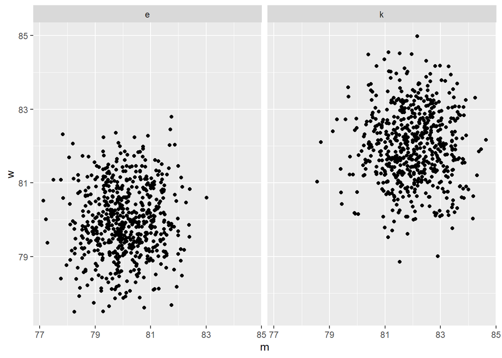

```r
t + facet_grid(. ~ c)
```

satıra bölmek için (yıllarda falan kullanıyoruz genelde)

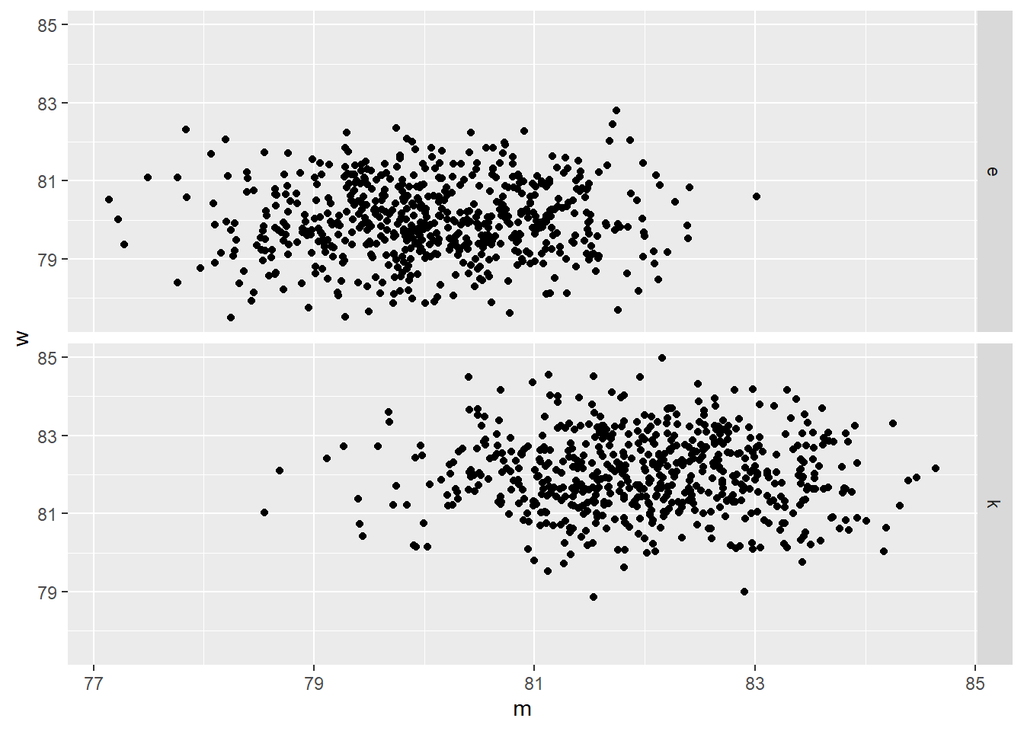

```r
t + facet_grid( c~ .)
```

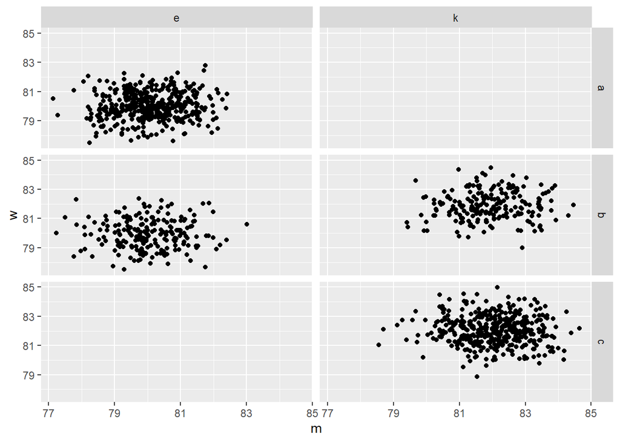

```r
t + facet_grid(me ~ c)
```

# 4. **ZAMAN SERİSİ GÖRSELLEŞTİRME**

```r
head(economics)
```

```
## # A tibble: 6 × 6
##   date         pce    pop psavert uempmed unemploy
##   <date>     <dbl>  <dbl>   <dbl>   <dbl>    <dbl>
## 1 1967-07-01  507. 198712    12.6     4.5     2944
## 2 1967-08-01  510. 198911    12.6     4.7     2945
## 3 1967-09-01  516. 199113    11.9     4.6     2958
## 4 1967-10-01  512. 199311    12.9     4.9     3143
## 5 1967-11-01  517. 199498    12.8     4.7     3066
## 6 1967-12-01  525. 199657    11.8     4.8     3018
```

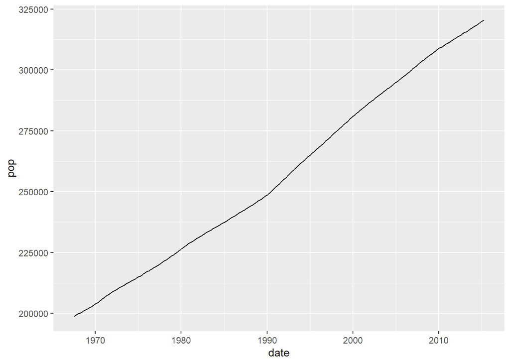

```r
d <- economics
ggplot(d , aes(date , pop)) +
  geom_line()
```

tarih değişkeninin tarih değişkeni olduğunu r a göstermemiz lazım. öncı yıl ay gün şeklindedir.

```r
head(economics)
```

```
## # A tibble: 6 × 6
##   date         pce    pop psavert uempmed unemploy
##   <date>     <dbl>  <dbl>   <dbl>   <dbl>    <dbl>
## 1 1967-07-01  507. 198712    12.6     4.5     2944
## 2 1967-08-01  510. 198911    12.6     4.7     2945
## 3 1967-09-01  516. 199113    11.9     4.6     2958
## 4 1967-10-01  512. 199311    12.9     4.9     3143
## 5 1967-11-01  517. 199498    12.8     4.7     3066
## 6 1967-12-01  525. 199657    11.8     4.8     3018
```

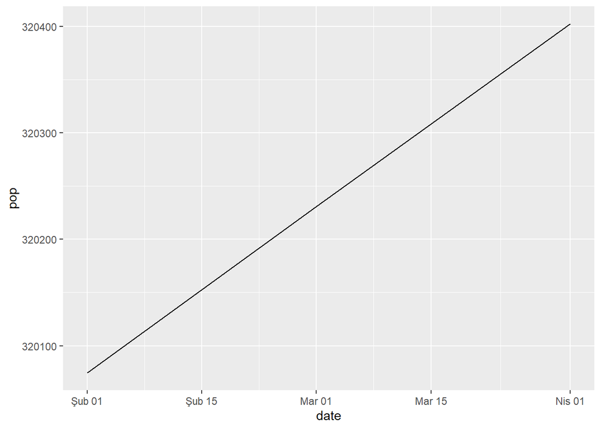

```r
d <- economics

s <- d %>% filter( date > as.Date("2015-1-25"))

ggplot(s, aes(date , pop)) +
  geom_line()
```

```r
head(economics)
```

```
## # A tibble: 6 × 6
##   date         pce    pop psavert uempmed unemploy
##   <date>     <dbl>  <dbl>   <dbl>   <dbl>    <dbl>
## 1 1967-07-01  507. 198712    12.6     4.5     2944
## 2 1967-08-01  510. 198911    12.6     4.7     2945
## 3 1967-09-01  516. 199113    11.9     4.6     2958
## 4 1967-10-01  512. 199311    12.9     4.9     3143
## 5 1967-11-01  517. 199498    12.8     4.7     3066
## 6 1967-12-01  525. 199657    11.8     4.8     3018
```

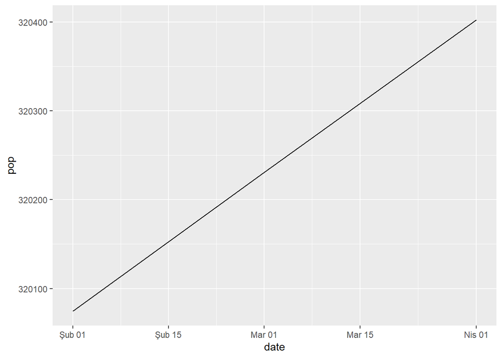

```r
d <- economics

s <- d %>% filter( date > as.Date("2015-1-25"))

ggplot(s, aes(date , pop)) +
  geom_line()
```

```r
#şurda geom_line içinde bir şey yazıyordu bak
```

#ÇOKLU ZAMAN SERİSİ GÖRSELLEŞTİRME

variable kategorik değişken iki tane değişkeni var. çizgi olarak gösterdik.

### ÇOKLU ZAMAN SERİSİNDE ÇİZGİ GRAFİĞİ

```r
df <- economics %>%
  select(date, psavert, uempmed) %>%
  gather(key = "variable" , value = "value" , -date)
head(df, 3)
```

```
## # A tibble: 3 × 3
##   date       variable value
##   <date>     <chr>    <dbl>
## 1 1967-07-01 psavert   12.6
## 2 1967-08-01 psavert   12.6
## 3 1967-09-01 psavert   11.9
```

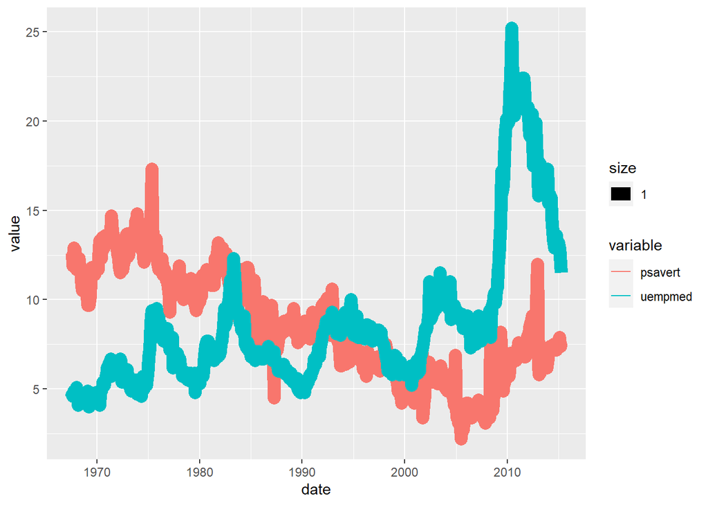

```r
ggplot(df, aes(date, value)) +
  geom_line(aes(color = variable , size = 1))
```

### ÇOKLU ZAMAN SERİSİNDE ALAN GRAFİĞİ

bitcoin ile ilgili zaman grafiği için uygun bir grafik olabilir.

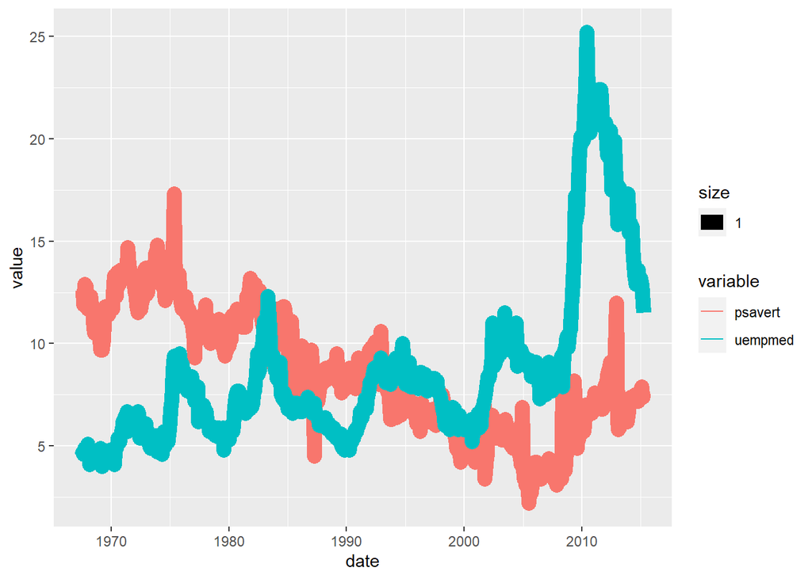

```r
library(tidyr)
df <- economics %>%
   select(date, psavert, uempmed) %>%
   gather(key = "variable" , value = "value" , -date)


ggplot(df, aes( date , value )) +
  geom_line(aes(color= variable , size = 1))
```

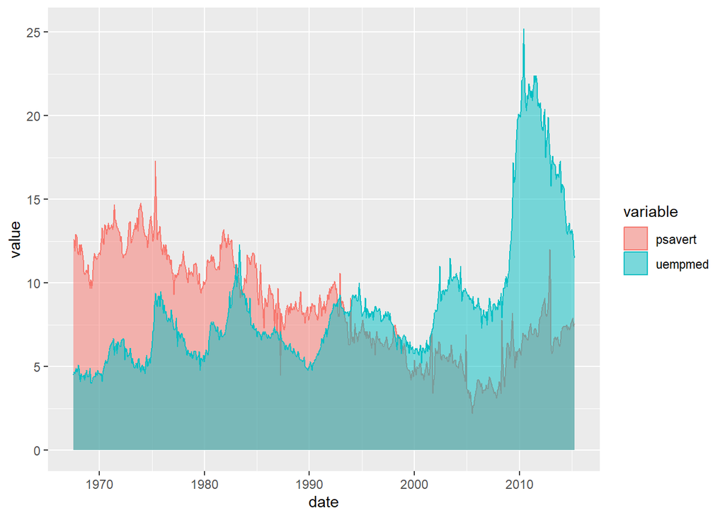

```r
ggplot(df, aes(date,value)) +
  geom_area(aes(color = variable, fill=variable),
            alpha= 0.5, position = position_dodge(0.8)
            )
```

# 5. **ÖRNEKLER**

## *MTCARS*

Öncelikle mtcars’ın içinde yer alan dataların kısaltmaları ne anlama geliyor inceliyoruz.

(https://rstudio-pubs-static.s3.amazonaws.com/61800_faea93548c6b49cc91cd0c5ef5059894.html)

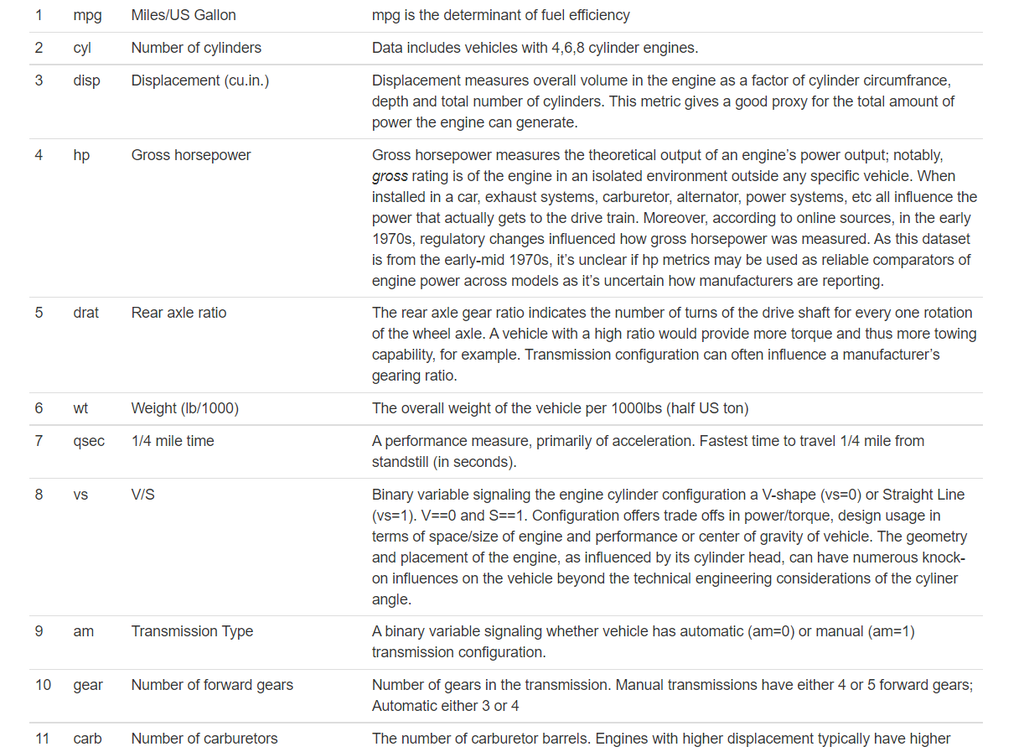

Datamızı çağıralım.

```r
mtcars
```

```
##                      mpg cyl  disp  hp drat    wt  qsec vs am gear carb
## Mazda RX4           21.0   6 160.0 110 3.90 2.620 16.46  0  1    4    4
## Mazda RX4 Wag       21.0   6 160.0 110 3.90 2.875 17.02  0  1    4    4
## Datsun 710          22.8   4 108.0  93 3.85 2.320 18.61  1  1    4    1
## Hornet 4 Drive      21.4   6 258.0 110 3.08 3.215 19.44  1  0    3    1
## Hornet Sportabout   18.7   8 360.0 175 3.15 3.440 17.02  0  0    3    2
## Valiant             18.1   6 225.0 105 2.76 3.460 20.22  1  0    3    1
## Duster 360          14.3   8 360.0 245 3.21 3.570 15.84  0  0    3    4
## Merc 240D           24.4   4 146.7  62 3.69 3.190 20.00  1  0    4    2
## Merc 230            22.8   4 140.8  95 3.92 3.150 22.90  1  0    4    2
## Merc 280            19.2   6 167.6 123 3.92 3.440 18.30  1  0    4    4
## Merc 280C           17.8   6 167.6 123 3.92 3.440 18.90  1  0    4    4
## Merc 450SE          16.4   8 275.8 180 3.07 4.070 17.40  0  0    3    3
## Merc 450SL          17.3   8 275.8 180 3.07 3.730 17.60  0  0    3    3
## Merc 450SLC         15.2   8 275.8 180 3.07 3.780 18.00  0  0    3    3
## Cadillac Fleetwood  10.4   8 472.0 205 2.93 5.250 17.98  0  0    3    4
## Lincoln Continental 10.4   8 460.0 215 3.00 5.424 17.82  0  0    3    4
## Chrysler Imperial   14.7   8 440.0 230 3.23 5.345 17.42  0  0    3    4
## Fiat 128            32.4   4  78.7  66 4.08 2.200 19.47  1  1    4    1
## Honda Civic         30.4   4  75.7  52 4.93 1.615 18.52  1  1    4    2
## Toyota Corolla      33.9   4  71.1  65 4.22 1.835 19.90  1  1    4    1
## Toyota Corona       21.5   4 120.1  97 3.70 2.465 20.01  1  0    3    1
## Dodge Challenger    15.5   8 318.0 150 2.76 3.520 16.87  0  0    3    2
## AMC Javelin         15.2   8 304.0 150 3.15 3.435 17.30  0  0    3    2
## Camaro Z28          13.3   8 350.0 245 3.73 3.840 15.41  0  0    3    4
## Pontiac Firebird    19.2   8 400.0 175 3.08 3.845 17.05  0  0    3    2
## Fiat X1-9           27.3   4  79.0  66 4.08 1.935 18.90  1  1    4    1
## Porsche 914-2       26.0   4 120.3  91 4.43 2.140 16.70  0  1    5    2
## Lotus Europa        30.4   4  95.1 113 3.77 1.513 16.90  1  1    5    2
## Ford Pantera L      15.8   8 351.0 264 4.22 3.170 14.50  0  1    5    4
## Ferrari Dino        19.7   6 145.0 175 3.62 2.770 15.50  0  1    5    6
## Maserati Bora       15.0   8 301.0 335 3.54 3.570 14.60  0  1    5    8
## Volvo 142E          21.4   4 121.0 109 4.11 2.780 18.60  1  1    4    2
```

Bazı istatiksel özelliklerini inceleyelim.

```r
str(mtcars)
```

```
## 'data.frame':    32 obs. of  11 variables:
##  $ mpg : num  21 21 22.8 21.4 18.7 18.1 14.3 24.4 22.8 19.2 ...
##  $ cyl : num  6 6 4 6 8 6 8 4 4 6 ...
##  $ disp: num  160 160 108 258 360 ...
##  $ hp  : num  110 110 93 110 175 105 245 62 95 123 ...
##  $ drat: num  3.9 3.9 3.85 3.08 3.15 2.76 3.21 3.69 3.92 3.92 ...
##  $ wt  : num  2.62 2.88 2.32 3.21 3.44 ...
##  $ qsec: num  16.5 17 18.6 19.4 17 ...
##  $ vs  : num  0 0 1 1 0 1 0 1 1 1 ...
##  $ am  : num  1 1 1 0 0 0 0 0 0 0 ...
##  $ gear: num  4 4 4 3 3 3 3 4 4 4 ...
##  $ carb: num  4 4 1 1 2 1 4 2 2 4 ...
```

```r
summary(mtcars)
```

```
##       mpg             cyl             disp             hp
##  Min.   :10.40   Min.   :4.000   Min.   : 71.1   Min.   : 52.0
##  1st Qu.:15.43   1st Qu.:4.000   1st Qu.:120.8   1st Qu.: 96.5
##  Median :19.20   Median :6.000   Median :196.3   Median :123.0
##  Mean   :20.09   Mean   :6.188   Mean   :230.7   Mean   :146.7
##  3rd Qu.:22.80   3rd Qu.:8.000   3rd Qu.:326.0   3rd Qu.:180.0
##  Max.   :33.90   Max.   :8.000   Max.   :472.0   Max.   :335.0
##       drat             wt             qsec             vs
##  Min.   :2.760   Min.   :1.513   Min.   :14.50   Min.   :0.0000
##  1st Qu.:3.080   1st Qu.:2.581   1st Qu.:16.89   1st Qu.:0.0000
##  Median :3.695   Median :3.325   Median :17.71   Median :0.0000
##  Mean   :3.597   Mean   :3.217   Mean   :17.85   Mean   :0.4375
##  3rd Qu.:3.920   3rd Qu.:3.610   3rd Qu.:18.90   3rd Qu.:1.0000
##  Max.   :4.930   Max.   :5.424   Max.   :22.90   Max.   :1.0000
##        am              gear            carb
##  Min.   :0.0000   Min.   :3.000   Min.   :1.000
##  1st Qu.:0.0000   1st Qu.:3.000   1st Qu.:2.000
##  Median :0.0000   Median :4.000   Median :2.000
##  Mean   :0.4062   Mean   :3.688   Mean   :2.812
##  3rd Qu.:1.0000   3rd Qu.:4.000   3rd Qu.:4.000
##  Max.   :1.0000   Max.   :5.000   Max.   :8.000
```

Mtcars’ın içinde yer alan verileri faktör haline getirelim.

```r
mtcars$cyl <- as.factor(mtcars$cyl)
mtcars$vs <- as.factor(mtcars$vs)
mtcars$am <- as.factor(mtcars$am)
mtcars$gear <- as.factor(mtcars$gear)
mtcars$carb <- as.factor(mtcars$carb)
```

faktör haline getirilmiş datamızdan herhangi sütununu çağırabiliyor muyuz diye test edelim.

```r
summary(mtcars$mpg)
```

```
##    Min. 1st Qu.  Median    Mean 3rd Qu.    Max.
##   10.40   15.43   19.20   20.09   22.80   33.90
```

Datamızda kayıp veri var mı? incelemesi yapalım.

```r
table(is.na(mtcars))
```

```
##
## FALSE
##   352
```

Mtcars datamız da yer alan sütunların isimlerini tekrar sorgulayalım. İsteği bağlı sütun ekleme ya da çıkartma yapılabilir. Fakat ben bu örnekte gerek duymadım.

```r
names(mtcars)
```

```
##  [1] "mpg"  "cyl"  "disp" "hp"   "drat" "wt"   "qsec" "vs"   "am"   "gear"
## [11] "carb"
```

**soru : Acaba otamatik ve manulel araçların galon başına mil ne kadar?** Bu sorunumuzu violin plot yardımıyla inceleyelim.

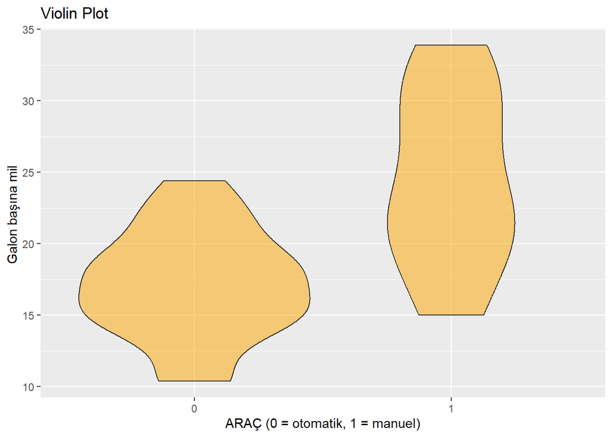

```r
df <- ggplot(data = mtcars, aes(x=am, y=mpg),
             draw_quantiles=TRUE)

df + geom_violin( fill = "orange" , alpha = 0.5) + labs(title="Violin Plot",  x="ARAÇ (0 = otomatik, 1 = manuel)",y="Galon başına mil ")
```

Grafik, otomatik vitesli araçlara göre manuel şanzımanlı araçlarda MPG içinbbir yükselişe sebep olmasını görüyoruz.

otomatik şanzımanlı araçlar için mpg’nin medyan çevresinde yoğun olduğu manuel için ilk yüzdelik( %25) dilim çevresinde yoğunluk olduğu görülmektedir.

**soru2- motor ve beygir gücünün ilişkisi hakkında ne diyebiliriz?**

yakıt verimliliğin beygir gücüne etkisi;

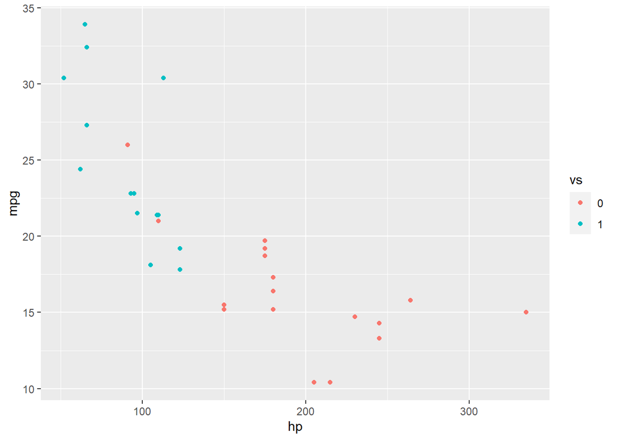

```r
ggplot(mtcars, aes(x = hp, y = mpg, color = vs)) +
  geom_point()
```

geom_smooth() komutu verideki trendi çizgi ile özetlemeyi grafiktir.

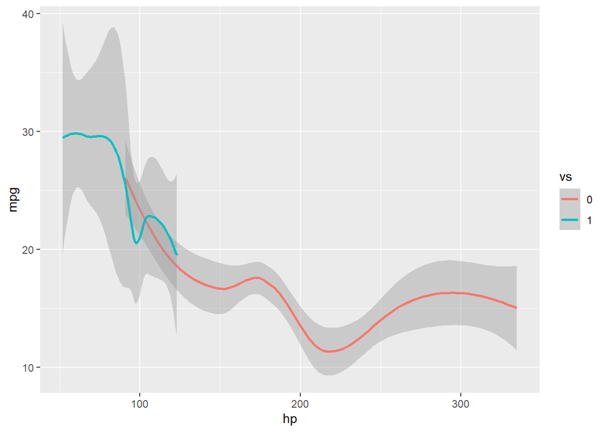

```r
ggplot(mtcars, aes(x = hp, y = mpg, color = vs)) +
geom_smooth( method = "loess" , formula = 'y ~ x')
```

Şimdi bu iki grafiği birleştiriyoruz;

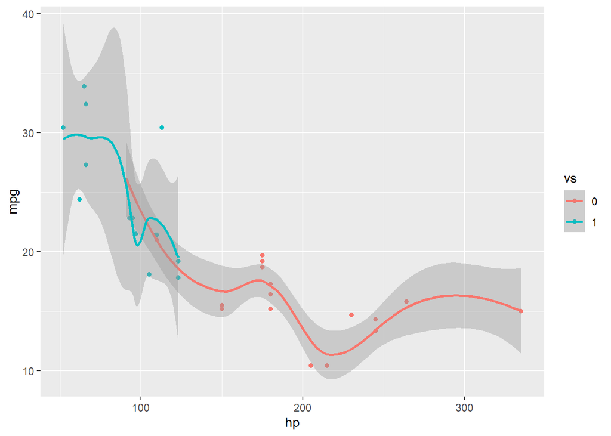

```r
ggplot(mtcars, aes(x = hp, y = mpg, color = vs)) +
  geom_point() + geom_smooth(method = "loess" , formula = 'y ~ x')
```

yorum: grafiğin birleşimleri aykırı değerleri bulmamıza yardımcı oldu.

Staright motorları için, daha düşük beygir(hp) gücünün ortalama ve maksimum değer arasında daha yüksek mpg verdiğini,

V-biçimli motorlarda ise, daha yüksek beygir gücüne(hp) rağmen mpg değerlerinin en küçük niceliksel aralıkta ortalamanın altına düştüğünü aktarır.

## *DİAMONDS*

Datamızı çağrıyoruz.

```r
diamonds
```

```
## # A tibble: 53,940 × 10
##    carat cut       color clarity depth table price     x     y     z
##    <dbl> <ord>     <ord> <ord>   <dbl> <dbl> <int> <dbl> <dbl> <dbl>
##  1  0.23 Ideal     E     SI2      61.5    55   326  3.95  3.98  2.43
##  2  0.21 Premium   E     SI1      59.8    61   326  3.89  3.84  2.31
##  3  0.23 Good      E     VS1      56.9    65   327  4.05  4.07  2.31
##  4  0.29 Premium   I     VS2      62.4    58   334  4.2   4.23  2.63
##  5  0.31 Good      J     SI2      63.3    58   335  4.34  4.35  2.75
##  6  0.24 Very Good J     VVS2     62.8    57   336  3.94  3.96  2.48
##  7  0.24 Very Good I     VVS1     62.3    57   336  3.95  3.98  2.47
##  8  0.26 Very Good H     SI1      61.9    55   337  4.07  4.11  2.53
##  9  0.22 Fair      E     VS2      65.1    61   337  3.87  3.78  2.49
## 10  0.23 Very Good H     VS1      59.4    61   338  4     4.05  2.39
## # … with 53,930 more rows
```

Verilerimizi incelemek için summary() komutunu çağrıyoruz.

```r
d <- diamonds
summary(d)
```

```
##      carat               cut        color        clarity          depth
##  Min.   :0.2000   Fair     : 1610   D: 6775   SI1    :13065   Min.   :43.00
##  1st Qu.:0.4000   Good     : 4906   E: 9797   VS2    :12258   1st Qu.:61.00
##  Median :0.7000   Very Good:12082   F: 9542   SI2    : 9194   Median :61.80
##  Mean   :0.7979   Premium  :13791   G:11292   VS1    : 8171   Mean   :61.75
##  3rd Qu.:1.0400   Ideal    :21551   H: 8304   VVS2   : 5066   3rd Qu.:62.50
##  Max.   :5.0100                     I: 5422   VVS1   : 3655   Max.   :79.00
##                                     J: 2808   (Other): 2531
##      table           price             x                y
##  Min.   :43.00   Min.   :  326   Min.   : 0.000   Min.   : 0.000
##  1st Qu.:56.00   1st Qu.:  950   1st Qu.: 4.710   1st Qu.: 4.720
##  Median :57.00   Median : 2401   Median : 5.700   Median : 5.710
##  Mean   :57.46   Mean   : 3933   Mean   : 5.731   Mean   : 5.735
##  3rd Qu.:59.00   3rd Qu.: 5324   3rd Qu.: 6.540   3rd Qu.: 6.540
##  Max.   :95.00   Max.   :18823   Max.   :10.740   Max.   :58.900
##
##        z
##  Min.   : 0.000
##  1st Qu.: 2.910
##  Median : 3.530
##  Mean   : 3.539
##  3rd Qu.: 4.040
##  Max.   :31.800
##
```

verileri inceliyoruz. bakıyorum *carat* belki sürekli değişken olabilir.

*cut* değişkeni yani kaliteleri ile ilgili bir değişken; *fair* good, very good, premium ıdeal bu kategorik olabilir peki ordinal mi diye merak ediyoruz ve bunu araştırıyorum. /str(d)/ ile yapılır.

```r
str(d)
```

```
## tibble [53,940 × 10] (S3: tbl_df/tbl/data.frame)
##  $ carat  : num [1:53940] 0.23 0.21 0.23 0.29 0.31 0.24 0.24 0.26 0.22 0.23 ...
##  $ cut    : Ord.factor w/ 5 levels "Fair"<"Good"<..: 5 4 2 4 2 3 3 3 1 3 ...
##  $ color  : Ord.factor w/ 7 levels "D"<"E"<"F"<"G"<..: 2 2 2 6 7 7 6 5 2 5 ...
##  $ clarity: Ord.factor w/ 8 levels "I1"<"SI2"<"SI1"<..: 2 3 5 4 2 6 7 3 4 5 ...
##  $ depth  : num [1:53940] 61.5 59.8 56.9 62.4 63.3 62.8 62.3 61.9 65.1 59.4 ...
##  $ table  : num [1:53940] 55 61 65 58 58 57 57 55 61 61 ...
##  $ price  : int [1:53940] 326 326 327 334 335 336 336 337 337 338 ...
##  $ x      : num [1:53940] 3.95 3.89 4.05 4.2 4.34 3.94 3.95 4.07 3.87 4 ...
##  $ y      : num [1:53940] 3.98 3.84 4.07 4.23 4.35 3.96 3.98 4.11 3.78 4.05 ...
##  $ z      : num [1:53940] 2.43 2.31 2.31 2.63 2.75 2.48 2.47 2.53 2.49 2.39 ...
```

*cut* olan değişkene bakıyorum ve evet diyorum, kategorik ve ordinal yani sıralı bir değişkendir.

*price* a karşılık bir *cut (kalite)* karşılaştırmak güzel olabilir. sınıf sayısı fazlalaşınca sıkıntı yaratılabilir.

ilk olarak price’ı görselleştirelim.

**Soru: Ürünlerimizin fiyat performansı nedir?**

Histogram grafiği ile yorumlamaya çalışalım.

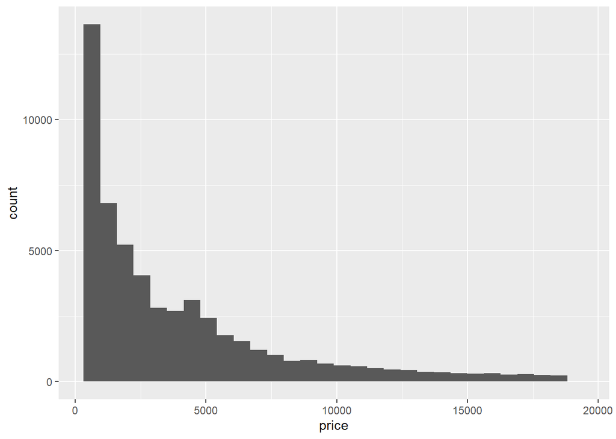

```r
ggplot(d, aes(price)) +
  geom_histogram()
```

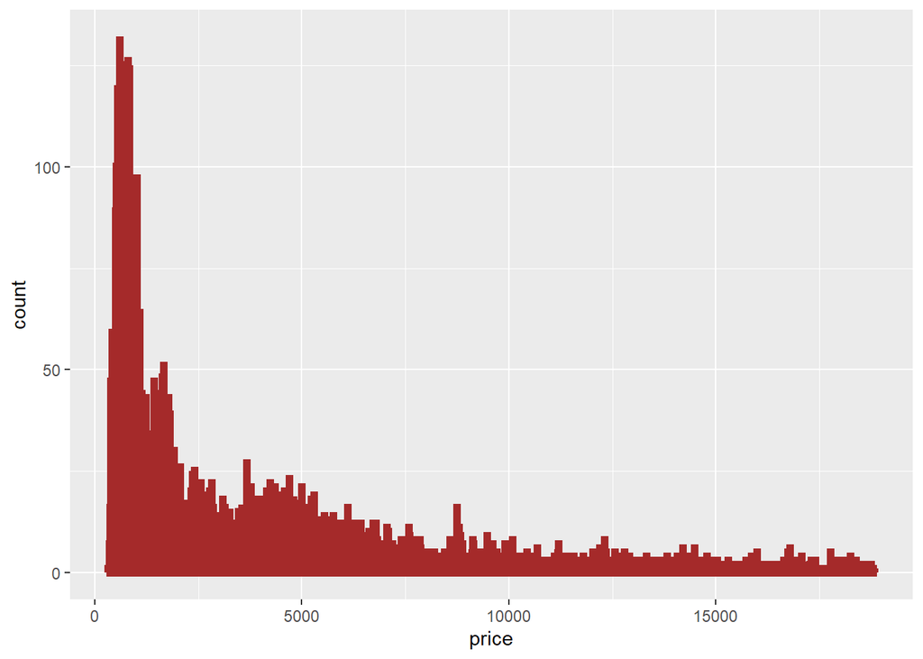

```r
ggplot(d, aes(price)) +
  geom_histogram(binwidth = 0.5, colour = "brown", size = 2  )
```

yorum : Satmış olduğumuz ürünlerin skalası var. fiyat dağılımı bu şekilde. ürünlerimin büyük bir çoğunluğu 5000 tlden daha az ürünleri kullanıyorlar.

Tüm veriyi temsil ediyor diye değerlendirmek yanlış olur. Bazı farklı yapılar olabilir. peki bu farklı yapıları nasıl analiz ederiz?

price’ı hangi kategorik değişkenler etkileyebilir? cut(kalite) olabilir. belki color (renk) olabilir.

prize’ın bazı kategorik değişkenlerdeki kırılımını meerak ediyoruz. Görselleştirmeden önce ölçmek istiyorum. ( d%>% )

ilk olarak cut’ı sınıflandırdık. sonra cut’a göre sınıflandırılmış değişkenlerin price ortalama fiyatını verecek.

```r
d %>% group_by(cut) %>%
  summarise(n=n() , ort= mean(price))
```

```
## # A tibble: 5 × 3
##   cut           n   ort
##   <ord>     <int> <dbl>
## 1 Fair       1610 4359.
## 2 Good       4906 3929.
## 3 Very Good 12082 3982.
## 4 Premium   13791 4584.
## 5 Ideal     21551 3458.
```

şimdi ortalamalar gözle görülür bir fark yok birbirlerine çok yakın çıktı.Hani sanki bu kategorik çok etkilemiyor gibi geldi.

```r
d %>% group_by(color) %>%
  summarise(n=n() , ort= mean(price))
```

```
## # A tibble: 7 × 3
##   color     n   ort
##   <ord> <int> <dbl>
## 1 D      6775 3170.
## 2 E      9797 3077.
## 3 F      9542 3725.
## 4 G     11292 3999.
## 5 H      8304 4487.
## 6 I      5422 5092.
## 7 J      2808 5324.
```

Sınıflar arası geçişler yumuşak ama çok sınıf olduğu için D ile J arasında geçiş farkı büyük.Histogramın farklılığı için bu farkı aldım verdim kabul ettim.

```r
d %>% group_by(clarity) %>%
  summarise(n=n() , ort= mean(price))
```

```
## # A tibble: 8 × 3
##   clarity     n   ort
##   <ord>   <int> <dbl>
## 1 I1        741 3924.
## 2 SI2      9194 5063.
## 3 SI1     13065 3996.
## 4 VS2     12258 3925.
## 5 VS1      8171 3839.
## 6 VVS2     5066 3284.
## 7 VVS1     3655 2523.
## 8 IF       1790 2865.
```

şimdi color bir kesikli değişken mi? Evet. ya bu kesikli değişkenin frekansı elimizde olcak ya da bu değere karşılık gelen mutluk değer net değer elimizde olmalı.

O zaman nasıl görselleştirebilirim? sütun, çizgi, nokta, pasta kullanabilirim.

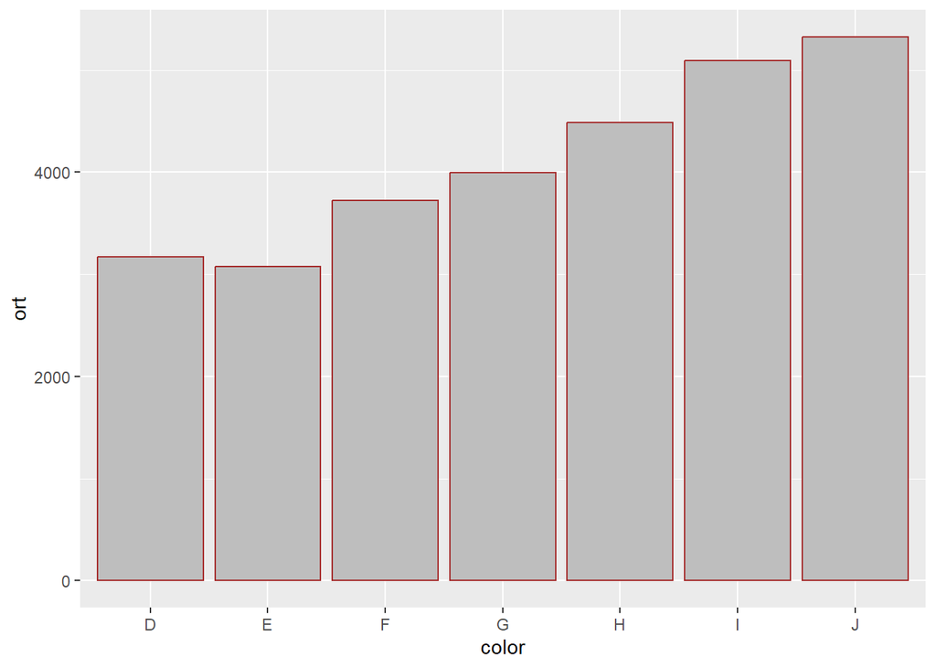

```r
k<- d %>% group_by(color) %>%
  summarise(n=n() , ort= mean(price))

ggplot(k, aes(color, ort)) +
  geom_bar(stat = "identity", color ="brown", fill = "gray")
```

yoğunluk grafiği

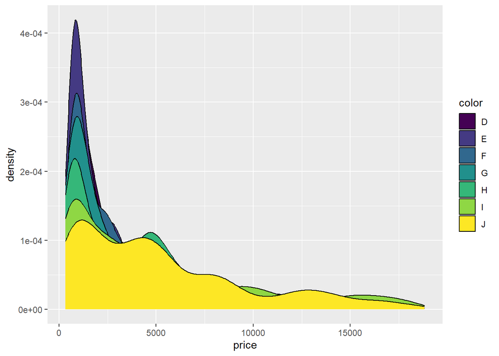

```r
ggplot(d, aes(price, fill =color)) +
  geom_density()
```

o ilk tablo ile karşılaştrıdık. (brown olan) aslında histograma gitmeye bile gerek yok çünkü istediğimize eriştik.

İlk grafikte dedikki tüm veriyi temsil eder mi? priceların yoğunluğunu tüm verinin yoğunluğu olarak mı ifade etmeliyim? tamam yoğunluğum bu ama bu yoğunluğu oluşturan etkenler ne gibi bir araştırmaya gitmiştik.

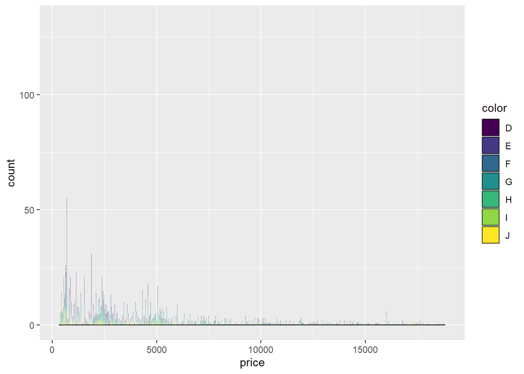

```r
 ggplot(d, aes(price, fill =color)) +
  geom_density() +
  geom_histogram(binwidth = 0.5, alpha= 0.5, possiton="identity")
```

# 6. **KAYNAKÇA**

Ders notlarımı oluştururken yardım aldığım eğitim platformları aşağıdaki gibidir.

### UDEMY

Yetişkinlere ve öğrencilere yönelik, alanında profesyonel gönüllü eğitmenler tarafından oluşturulan kursları içeren eğitim teknolojisi, kitlesel çevrimiçi açık ders ve bir çevrimiçi öğrenme platformudur. [https://tr.wikipedia.org/wiki/Udemy]

[udemy](https://www.udemy.com/course/r-programlama/)

[figure not shown]

### DataCamp

Datacamp, veri bilimleri ile ilgilenen ve bu konuda kendini geliştirmek isteyen herkes için kolaylık sağlayan bir eğitim sitesidir. [ https://www.abprojeyonetimi.com/datacamp-nedir-ne-ise-yarar/]

[datacamp](https://app.datacamp.com/learn/courses/reporting-with-rmarkdown)

[figure not shown]

### Mimar Sinan Güzel Sanatlar Üniversitesi

İleri düzey R programlama dersi esnansında aklımda kalan bilgilerin ders notumu hazırlamamda etkisi büyüktür.

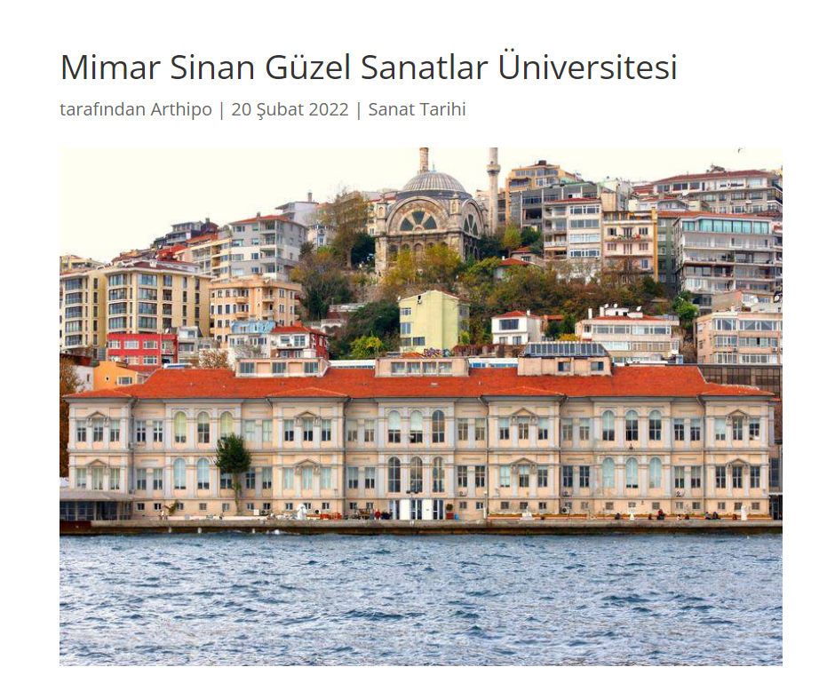